# Lecture 5: Sampling, Estimation and Statistical Inference Workshop

Sharon Tan

12 September 2022

# Building Dashboards for Bank Credit Risk Analyses

**Last two weeks, we started building the Bank Credit Risk Analyses Dashboards. This week we will focus on using the data for estimation and hypothesis testing.**

## 1) Preparation

*- Start by installing the packges you need. I will set message=FALSE and warning=FALSE so they will not show up in the HTML output.*

### Install Packages

```r
#install.packages("psych") #only need to run this code once to install the package

library("rcompanion") #this package is required for transformTukey function
library("rstatix") # for Welch ANOVA & Games Howell test
library("Rmisc") # For computation of CI
library("dplyr")
library("tidyr")
library("rpivotTable")
library("knitr")
library("psych")
```

### Set Working Directory and Importing Data

The worksheet Base Data in the Excel file Bank Credit Risk Data provides information about **a sample of** 425 bank customers who had applied for loans. Each of the column is defined as follows:

- `Loan Purpose` : Type of purpose for the loan applied
- `Checking` : Checking account balance
- `Savings` : Savings account balance
- `Months Customer`: Number of months has been a customer of the bank
- `Months Employed`: Number of months in employment
- `Gender`: Gender
- `Marital Status`: Marital status
- `Age`: Age in years
- `Housing`: Housing type
- `Years`: Number of years at current residence
- `Job`: Job type
- `Credit Risk`: Credit-risk classification by the bank

*- Be sure to set working directory and import the datafile.*

### Checking Data

*- Check that you have entered the data correctly by using the head() and summary() functions.*

```r
head(BD)
```

```
## # A tibble: 6 × 12
##   `Loan Purpose`  Checking Savings `Months Customer` `Months Employed` Gender
##   <chr>              <dbl>   <dbl>             <dbl>             <dbl> <chr>
## 1 Small Appliance        0     739                13                12 M
## 2 Furniture              0    1230                25                 0 M
## 3 New Car                0     389                19               119 M
## 4 Furniture            638     347                13                14 M
## 5 Education            963    4754                40                45 M
## 6 Furniture           2827       0                11                13 M
## # … with 6 more variables: Marital Status <chr>, Age <dbl>, Housing <chr>,
## #   Years <dbl>, Job <chr>, Credit Risk <chr>
```

```r
summary(BD)
```

```
##  Loan Purpose          Checking        Savings      Months Customer
##  Length:425         Min.   :    0   Min.   :    0   Min.   : 5.0
##  Class :character   1st Qu.:    0   1st Qu.:  228   1st Qu.:13.0
##  Mode  :character   Median :    0   Median :  596   Median :19.0
##                     Mean   : 1048   Mean   : 1813   Mean   :22.9
##                     3rd Qu.:  560   3rd Qu.:  921   3rd Qu.:28.0
##                     Max.   :19812   Max.   :19811   Max.   :73.0
##  Months Employed    Gender          Marital Status          Age
##  Min.   :  0.0   Length:425         Length:425         Min.   :18.0
##  1st Qu.:  6.0   Class :character   Class :character   1st Qu.:26.0
##  Median : 20.0   Mode  :character   Mode  :character   Median :32.0
##  Mean   : 31.9                                         Mean   :34.4
##  3rd Qu.: 47.0                                         3rd Qu.:41.0
##  Max.   :119.0                                         Max.   :73.0
##    Housing              Years          Job            Credit Risk
##  Length:425         Min.   :1.00   Length:425         Length:425
##  Class :character   1st Qu.:2.00   Class :character   Class :character
##  Mode  :character   Median :3.00   Mode  :character   Mode  :character
##                     Mean   :2.84
##                     3rd Qu.:4.00
##                     Max.   :4.00
```

```r
str(BD) #You can view this in the Global Environment window
```

```
## tibble [425 × 12] (S3: tbl_df/tbl/data.frame)
##  $ Loan Purpose   : chr [1:425] "Small Appliance" "Furniture" "New Car" "Furniture" ...
##  $ Checking       : num [1:425] 0 0 0 638 963 ...
##  $ Savings        : num [1:425] 739 1230 389 347 4754 ...
##  $ Months Customer: num [1:425] 13 25 19 13 40 11 13 14 37 25 ...
##  $ Months Employed: num [1:425] 12 0 119 14 45 13 16 2 9 4 ...
##  $ Gender         : chr [1:425] "M" "M" "M" "M" ...
##  $ Marital Status : chr [1:425] "Single" "Divorced" "Single" "Single" ...
##  $ Age            : num [1:425] 23 32 38 36 31 25 26 27 25 43 ...
##  $ Housing        : chr [1:425] "Own" "Own" "Own" "Own" ...
##  $ Years          : num [1:425] 3 1 4 2 3 1 3 1 2 1 ...
##  $ Job            : chr [1:425] "Unskilled" "Skilled" "Management" "Unskilled" ...
##  $ Credit Risk    : chr [1:425] "Low" "High" "High" "High" ...
```

## 2) Descriptive Statistics for Customer Age

### A) Statistical Summary for Customer Age

```r
# Manually generate each summary statistic (mean, sd, min, max, median) then combine into a table
Age<-cbind(mean(BD$Age),sd(BD$Age),min(BD$Age),max(BD$Age),median(BD$Age))
kable(Age,
      row.names = FALSE,
      col.names = c("Mean","Std Dev", "Min","Max","Median"),
      caption = "Descriptive Statistics for Age - manual",
      digits=3)
```

Descriptive Statistics for Age - manual

| Mean | Std Dev | Min | Max | Median |
| --- | --- | --- | --- | --- |
| 34.398 | 11.045 | 18 | 73 | 32 |

```r
# Use describe() function in psych package to generate the descriptive statistics
dfage <- describe(BD$Age, IQR=TRUE)
dfage$trimmed <- dfage$mad  <- NULL # remove mad and trimmed if not needed
dfage$vars[1]<-"Age"
kable(dfage,
      row.names = FALSE,
      caption = "Descriptive Statistics for Age - using psych package",
      digits=3)
```

Descriptive Statistics for Age - using psych package

| vars | n | mean | sd | median | min | max | range | skew | kurtosis | se | IQR |
| --- | --- | --- | --- | --- | --- | --- | --- | --- | --- | --- | --- |
| Age | 425 | 34.398 | 11.045 | 32 | 18 | 73 | 55 | 0.961 | 0.403 | 0.536 | 15 |

### B) Histogram & Frequency Distribution for Customer Age

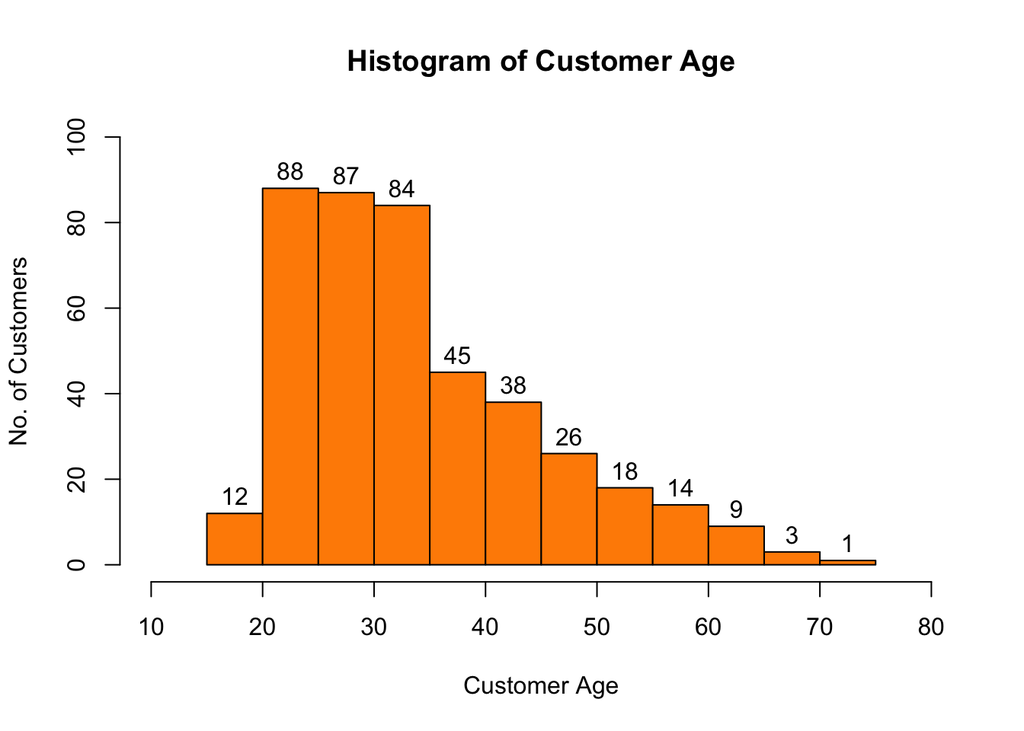

```r
# Age
# create histogram
h1<-hist(BD$Age, main="Histogram of Customer Age",xlab="Customer Age",ylab="No. of Customers", col=c("darkorange"),xlim=c(10,80),ylim=c(0,100), labels=TRUE)
```

```r
# extract frequency table from hist()
Age.Group<-cut(BD$Age,h1$breaks)
t1<-table(Age.Group)
kable(t1, caption = "Frequency distribution by Age Group")
```

Frequency distribution by Age Group

| Age.Group | Freq |
| --- | --- |
| (15,20] | 12 |
| (20,25] | 88 |
| (25,30] | 87 |
| (30,35] | 84 |
| (35,40] | 45 |
| (40,45] | 38 |
| (45,50] | 26 |
| (50,55] | 18 |
| (55,60] | 14 |
| (60,65] | 9 |
| (65,70] | 3 |
| (70,75] | 1 |